# CENG 3516 STATISTICAL COMPUTING FINAL PROJECT

İrem Uslu-Hatice Özgül Bilici

# Description of Data

It is a data set of customer databases of an e-commerce company selling international electronic products.This data set contains 10999 observations and 12 variables.My aim in this project was to observe the relationships between the company’s products and its customers.

https://www.kaggle.com/datasets/prachi13/customer-analytics

## Dataset Information

| Column | Description |
| --- | --- |
| ID | ID Number of Customers. |
| Warehouse Block | The Company have big Warehouse which is divided in to block such as A,B,C,D,F. |
| Mode of shipment | The Company Ships the products in multiple way such as Ship, Flight and Road. |
| Customer care calls | The number of calls made from enquiry for enquiry of the shipment. |
| Customer rating | The company has rated from every customer. 1 is the lowest (Worst), 5 is the highest (Best). |
| Cost of the product | Cost of the Product in US Dollars. |
| Prior purchases | The Number of Prior Purchase. |
| Product importance | Total number of applications |
| Gender | Total number of applications |
| Discount offered | Discount offered on that specific product. |
| Weight in gms | It is the weight in grams. |
| Reached on time | It is the target variable, where 1 Indicates that the product has NOT reached on time and 0 indicates it has reached on time. |

```r
options(warn=-1)
```

# Import Libraries

```r
library(stats)
library(ggplot2)
library(MASS)
library(plyr)
library(nortest)
library("dplyr", warn.conflicts = FALSE)
library(GGally)
```

# Loading Data

```r
data <- read.csv("train.csv",sep=",")
```

# Data Exploration

It shows the first 6 observations and 12 variables of the dataset.

```r
head(data)
```

```
##   ï..ID Warehouse_block Mode_of_Shipment Customer_care_calls Customer_rating
## 1     1               D           Flight                   4               2
## 2     2               F           Flight                   4               5
## 3     3               A           Flight                   2               2
## 4     4               B           Flight                   3               3
## 5     5               C           Flight                   2               2
## 6     6               F           Flight                   3               1
##   Cost_of_the_Product Prior_purchases Product_importance Gender
## 1                 177               3                low      F
## 2                 216               2                low      M
## 3                 183               4                low      M
## 4                 176               4             medium      M
## 5                 184               3             medium      F
## 6                 162               3             medium      F
##   Discount_offered Weight_in_gms Reached.on.Time_Y.N
## 1               44          1233                   1
## 2               59          3088                   1
## 3               48          3374                   1
## 4               10          1177                   1
## 5               46          2484                   1
## 6               12          1417                   1
```

```r
colnames(data)
```

```
##  [1] "ï..ID"               "Warehouse_block"     "Mode_of_Shipment"
##  [4] "Customer_care_calls" "Customer_rating"     "Cost_of_the_Product"
##  [7] "Prior_purchases"     "Product_importance"  "Gender"
## [10] "Discount_offered"    "Weight_in_gms"       "Reached.on.Time_Y.N"
```

We edited the column names and made them more understandable.

```r
colnames(data) <- c("customer_id", "warehouse_block",
                       "mode_of_shipment", "customer_care_calls", "customer_rating","cost_product", "prior_purchase","product_importance","gender","discount_offered","weight_gms","reached_on_time")
```

```r
colnames(data)
```

```
##  [1] "customer_id"         "warehouse_block"     "mode_of_shipment"
##  [4] "customer_care_calls" "customer_rating"     "cost_product"
##  [7] "prior_purchase"      "product_importance"  "gender"
## [10] "discount_offered"    "weight_gms"          "reached_on_time"
```

```r
data <- transform(data, reached_on_time = as.factor(mapvalues(reached_on_time, c(0,1), c("notReached","Reached"))))
data$warehouse_block<- factor(data$warehouse_block)
data$mode_of_shipment<- factor(data$mode_of_shipment)
data$gender<- factor(data$gender)
data$product_importance<- factor(data$product_importance)
```

```r
summary(data)
```

```
##   customer_id    warehouse_block mode_of_shipment customer_care_calls
##  Min.   :    1   A:1833          Flight:1777      Min.   :2.000
##  1st Qu.: 2750   B:1833          Road  :1760      1st Qu.:3.000
##  Median : 5500   C:1833          Ship  :7462      Median :4.000
##  Mean   : 5500   D:1834                           Mean   :4.054
##  3rd Qu.: 8250   F:3666                           3rd Qu.:5.000
##  Max.   :10999                                    Max.   :7.000
##  customer_rating  cost_product   prior_purchase   product_importance gender
##  Min.   :1.000   Min.   : 96.0   Min.   : 2.000   high  : 948        F:5545
##  1st Qu.:2.000   1st Qu.:169.0   1st Qu.: 3.000   low   :5297        M:5454
##  Median :3.000   Median :214.0   Median : 3.000   medium:4754
##  Mean   :2.991   Mean   :210.2   Mean   : 3.568
##  3rd Qu.:4.000   3rd Qu.:251.0   3rd Qu.: 4.000
##  Max.   :5.000   Max.   :310.0   Max.   :10.000
##  discount_offered   weight_gms     reached_on_time
##  Min.   : 1.00    Min.   :1001   notReached:4436
##  1st Qu.: 4.00    1st Qu.:1840   Reached   :6563
##  Median : 7.00    Median :4149
##  Mean   :13.37    Mean   :3634
##  3rd Qu.:10.00    3rd Qu.:5050
##  Max.   :65.00    Max.   :7846
```

```r
summary(data$warehouse_block)
```

```
##    A    B    C    D    F
## 1833 1833 1833 1834 3666
```

```r
summary(data$mode_of_shipment)
```

```
## Flight   Road   Ship
##   1777   1760   7462
```

```r
summary(data$gender)
```

```
##    F    M
## 5545 5454
```

```r
summary(data$cost_product)
```

```
##    Min. 1st Qu.  Median    Mean 3rd Qu.    Max.
##    96.0   169.0   214.0   210.2   251.0   310.0
```

```r
summary(data$customer_care_calls)
```

```
##    Min. 1st Qu.  Median    Mean 3rd Qu.    Max.
##   2.000   3.000   4.000   4.054   5.000   7.000
```

# Data visualization

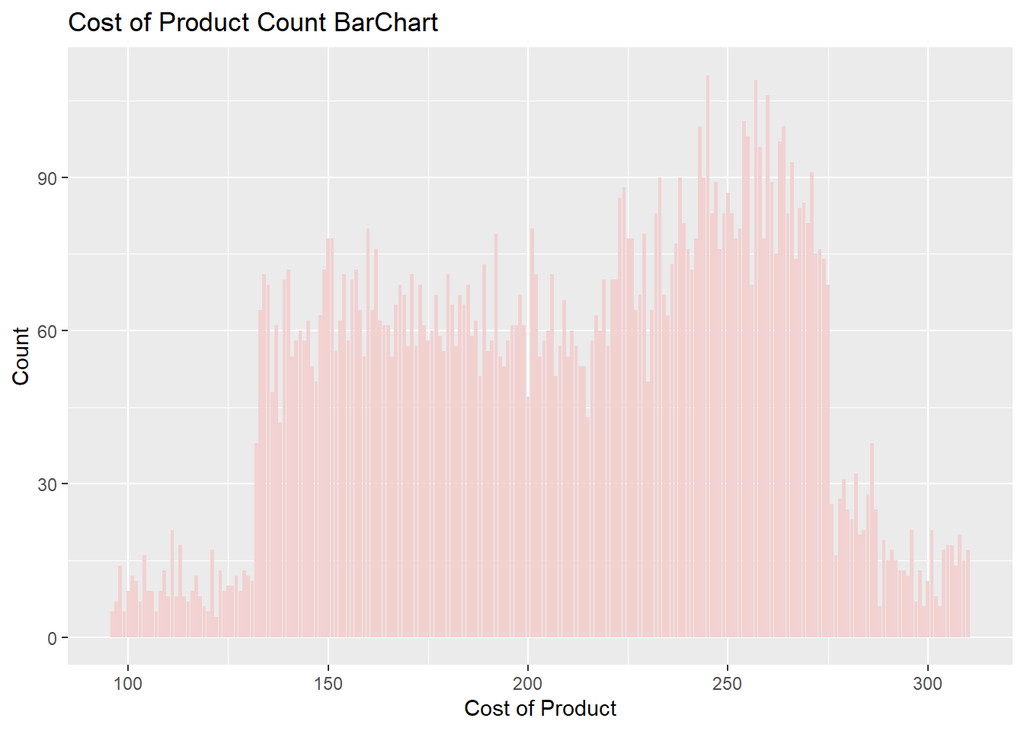

```r
ggplot(data=data, aes(x=cost_product)) +
  geom_bar(fill="#F2D1D1")+
  labs(title = "Cost of Product Count BarChart", x="Cost of Product", y="Count")
```

We see that most of the product prices on the e-commerce site are below or above 250 dollars.

```r
totalProduct <- aggregate(weight_gms~mode_of_shipment,data,sum)
head(totalProduct)
```

```
##   mode_of_shipment weight_gms
## 1           Flight    6449405
## 2             Road    6423209
## 3             Ship   27097936
```

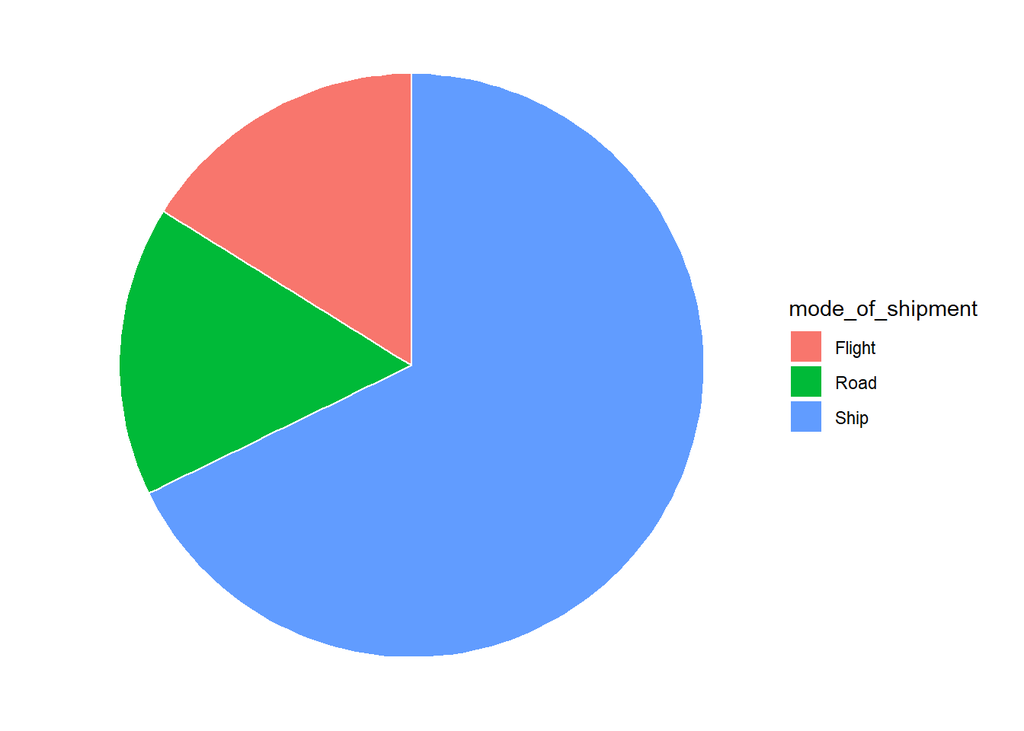

```r
ggplot(totalProduct, aes(x="", y=weight_gms, fill=mode_of_shipment)) +
  geom_bar(stat="identity", width=1, color="white") +
  coord_polar("y", start=0) +
  theme_void()
```

It is seen that the heaviest products in grams are mostly shipped by sea.

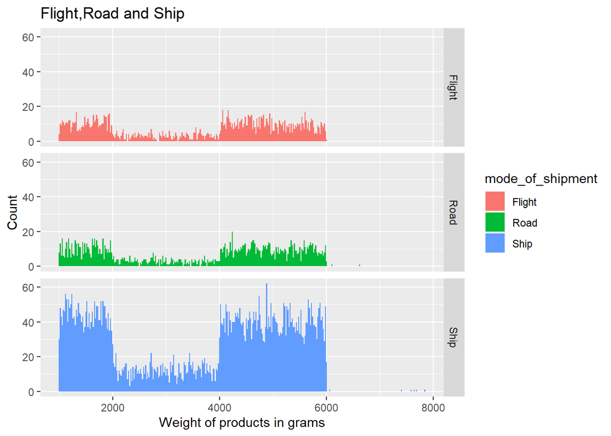

```r
ggplot(data, aes(weight_gms, fill=mode_of_shipment)) +
  geom_histogram(position="identity", binwidth=20) +
  facet_grid(mode_of_shipment ~ .) +
  ggtitle("Flight,Road and Ship") +
  xlab("Weight of products in grams") +
  ylab("Count")
```

As we can see in the histogram graphics above, the heaviest products are sent by ship cargo.

```r
totalImportance <- aggregate(weight_gms~product_importance,data,sum)
head(totalImportance)
```

```
##   product_importance weight_gms
## 1               high    3797263
## 2                low   18526199
## 3             medium   17647088
```

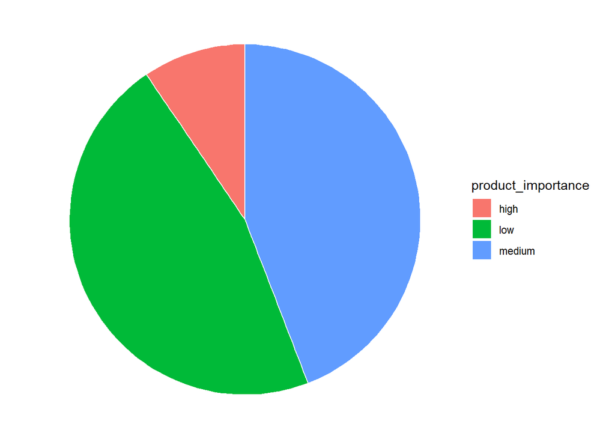

```r
ggplot(totalImportance, aes(x="", y=weight_gms, fill=product_importance)) +
  geom_bar(stat="identity", width=1, color="white") +
  coord_polar("y", start=0) +
  theme_void()
```

As seen in the pie chart, we cannot make a definite judgment about the total weight of the transported product, even if the transported product is of great importance. The pie slice tells us that the product with the lowest value has a higher total weight.

```r
totalDiscount <- aggregate(discount_offered~product_importance,data,sum)
head(totalDiscount)
```

```
##   product_importance discount_offered
## 1               high            13904
## 2                low            69089
## 3             medium            64099
```

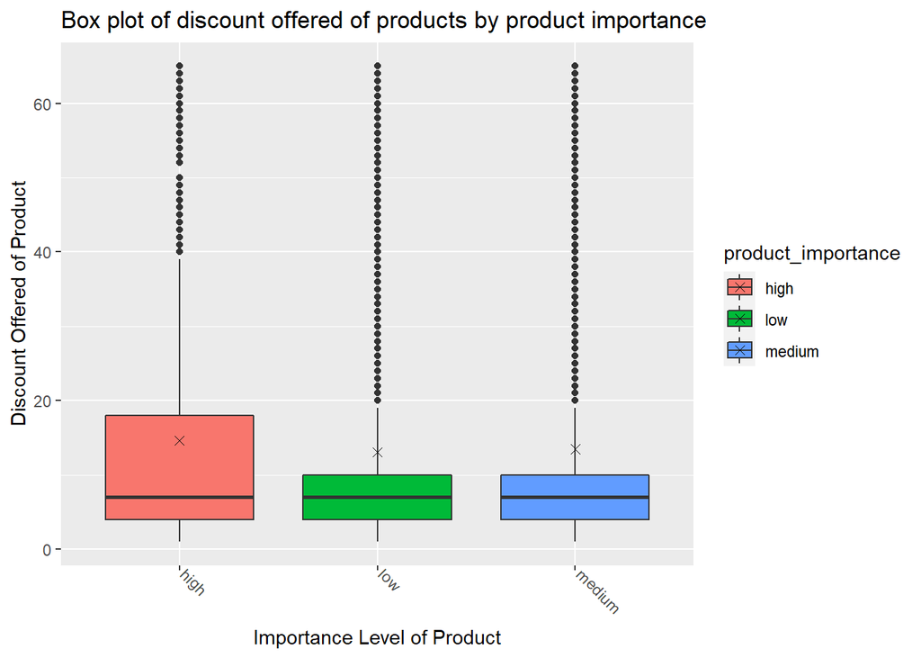

```r
ggplot(data=data, aes(x=product_importance, y=discount_offered, fill= product_importance)) +
  geom_boxplot() +
  labs(title = "Box plot of discount offered of products by product importance", x = "Importance Level of Product", y="Discount Offered of Product") +
  stat_summary(fun=mean, geom="point", shape=4, size=2) +
  theme(axis.text.x=element_text(angle=-45,hjust=0,vjust=0))
```

Most of the discounts have been made on low quality products.Discounts of 20 or more on low and medium quality products are outliers, while values of 40 and above on high quality products are outliers.

```r
totalPp <- aggregate(prior_purchase~product_importance,data,sum)
head(totalPp)
```

```
##   product_importance prior_purchase
## 1               high           3467
## 2                low          18689
## 3             medium          17084
```

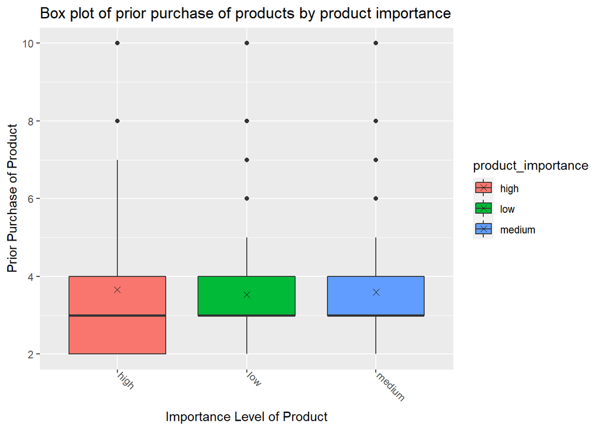

```r
ggplot(data=data, aes(x=product_importance, y=prior_purchase, fill= product_importance)) +
  geom_boxplot() +
  labs(title = "Box plot of prior purchase of products by product importance", x = "Importance Level of Product", y="Prior Purchase of Product") +
  stat_summary(fun=mean, geom="point", shape=4, size=2) +
  theme(axis.text.x=element_text(angle=-45,hjust=0,vjust=0))
```

Low-importance products were the most preferred among previously purchased products.

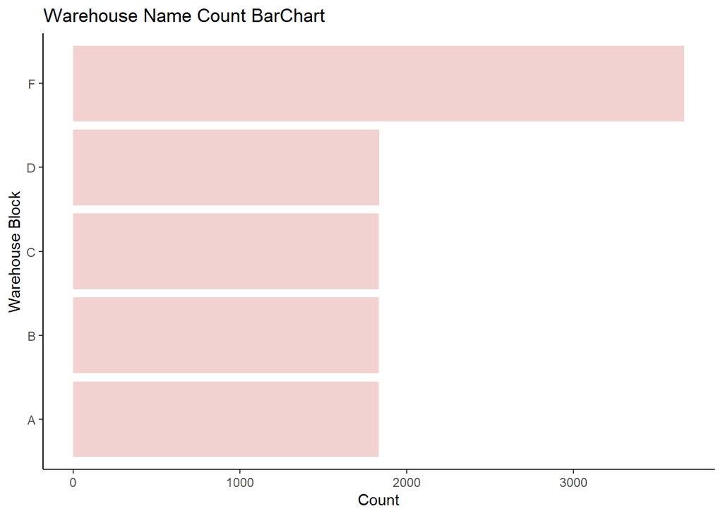

```r
line<-filter(summarise(group_by(data,warehouse_block), Count=length(warehouse_block)),Count>100)
ggplot(line,aes(x=warehouse_block,y=Count))+geom_col(fill='#F2D1D1')+coord_flip()+theme_classic() +labs(title = "Warehouse Name Count BarChart", x="Warehouse Block")
```

There are 5 different warehouse blocks where the products are stocked. Among these blocks, the F block has the most products, while the other blocks have the same number of products.

```r
importance<-data.frame(table(data$product_importance,data$gender))
colnames(importance) <- c("product_importance", "gender","count")
importance
```

```
##   product_importance gender count
## 1               high      F   470
## 2                low      F  2652
## 3             medium      F  2423
## 4               high      M   478
## 5                low      M  2645
## 6             medium      M  2331
```

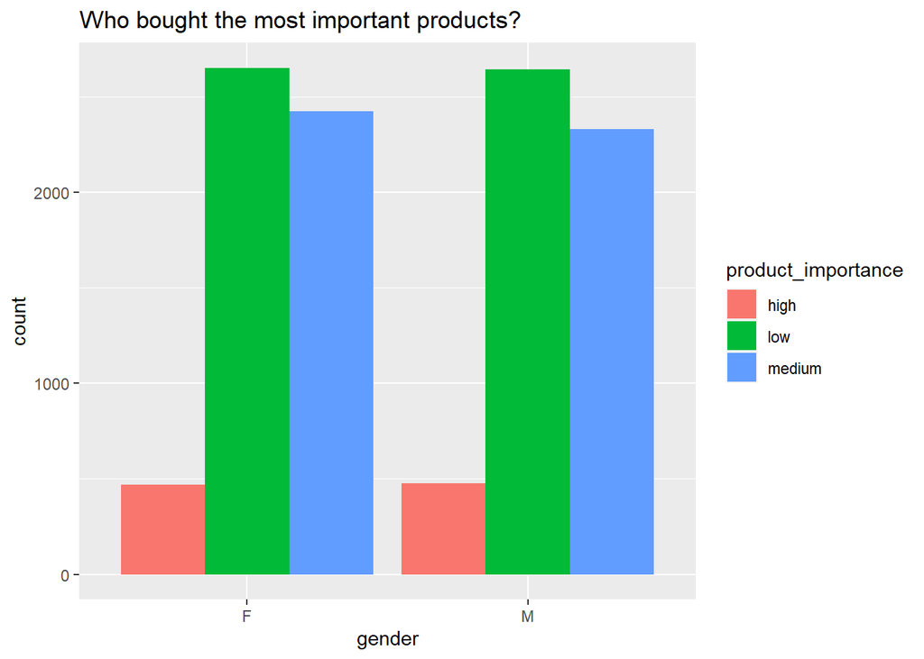

```r
ggplot(importance, aes(x=gender, y=count, fill=product_importance)) + geom_bar(position="dodge", stat="identity")+
  labs(title = "Who bought the most important products?")
```

With a slight difference, men bought more from the most important products, while women bought the most from medium and low importance products.

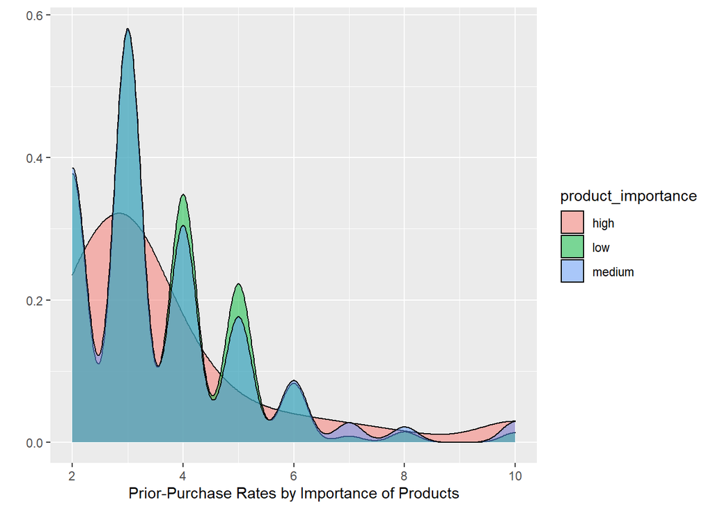

```r
qplot(fill = product_importance,
      x = prior_purchase,
      data = data,
      geom = "density",
      alpha = I(0.5),
      adjust = 2
      )+ labs( x = "Prior-Purchase Rates by Importance of Products")
```

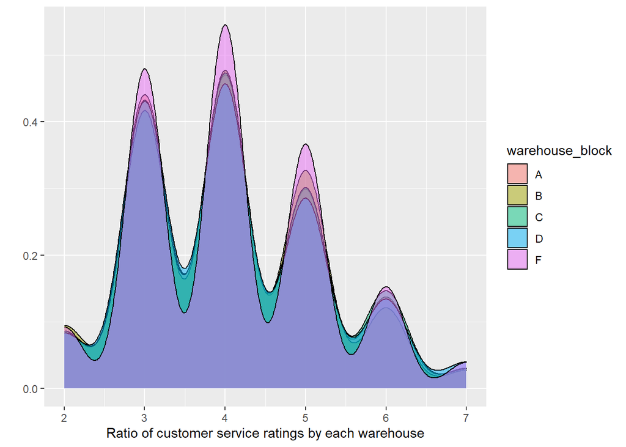

```r
qplot(fill = warehouse_block,
      x = customer_care_calls,
      data = data,
      geom = "density",
      alpha = I(0.5),
      adjust = 1.2
      )+ labs( x = "Ratio of customer service ratings by each warehouse")
```

# Confidence Intervals

## 1)Confidence interval that evaluates how many previous purchases of a product that reaches the customer or does not reach the customer.

```r
reached <- subset(data, reached_on_time=="Reached")
notReached <- subset(data, reached_on_time=="notReached")
```

```r
reachedConf <- t.test(reached$prior_purchase)$conf.int
reachedConf
```

```
## [1] 3.46138 3.53481
## attr(,"conf.level")
## [1] 0.95
```

The above output shows that the average of prior purchased products for reached products is between 3.46138 and 3.53481 with 95% confidence.

```r
notReachedConf <- t.test(notReached$prior_purchase)$conf.int
notReachedConf
```

```
## [1] 3.625522 3.715326
## attr(,"conf.level")
## [1] 0.95
```

The above output shows that the average of prior purchased products for not reached products is between 3.625522 and 3.715326 with 95% confidence.

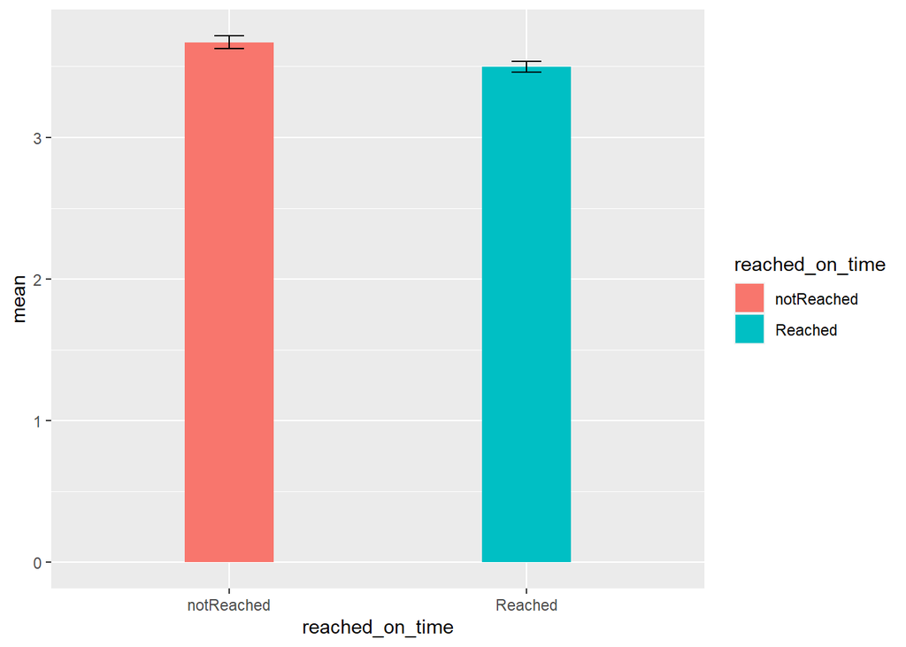

```r
reach.purchase <- data.frame(reached_on_time="Reached",
                                mean=mean(reached$prior_purchase),
                                lower=reachedConf[1],
                                upper=reachedConf[2])

reach.purchase <- rbind(reach.purchase , data.frame(reached_on_time="notReached",
                                mean=mean(notReached$prior_purchase),
                                lower=notReachedConf[1],
                                upper=notReachedConf[2]))


ggplot(reach.purchase, aes(x=reached_on_time, y=mean, fill=reached_on_time)) +
  geom_bar(position="dodge", stat="identity", width = 0.3) +
  geom_errorbar(aes(ymin=lower, ymax=upper),
                width=.1,
                position=position_dodge(0.1))
```

## 2)Confidence interval that evaluates the total price of products purchased by the customer’s gender.

```r
female <- subset(data, gender=="F")
male <- subset(data, gender=="M")
```

```r
femaleConf <- t.test(female$cost_product)$conf.int
femaleConf
```

```
## [1] 207.9892 210.5208
## attr(,"conf.level")
## [1] 0.95
```

The above output shows that the true average product price for women is between 207.9892 and 210.5208 with 95% confidence.

```r
maleConf<- t.test(male$cost_product)$conf.int
maleConf
```

```
## [1] 209.8794 212.4293
## attr(,"conf.level")
## [1] 0.95
```

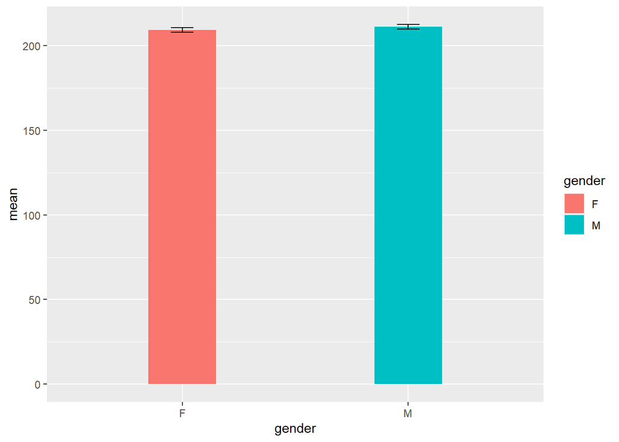

```r
gender.cost_product <- data.frame(gender="F",
                                mean=mean(female$cost_product),
                                lower=femaleConf[1],
                                upper=femaleConf[2])

gender.cost_product<- rbind(gender.cost_product , data.frame(gender="M",
                                mean=mean(male$cost_product),
                                lower=maleConf[1],
                                upper=maleConf[2]))

ggplot(gender.cost_product, aes(x=gender, y=mean, fill=gender)) +
  geom_bar(position="dodge", stat="identity", width = 0.3) +
  geom_errorbar(aes(ymin=lower, ymax=upper),
                width=.1,
                position=position_dodge(0.1))
```

## 3)Confidence interval that evaluates customer service search by repository block.

```r
a <- subset(data, warehouse_block=="A")
b <- subset(data, warehouse_block=="B")
c <- subset(data, warehouse_block=="C")
d <- subset(data, warehouse_block=="D")
f <- subset(data, warehouse_block=="F")
```

```r
aConf <- t.test(a$customer_care_calls)$conf.int
aConf
```

```
## [1] 3.986027 4.090351
## attr(,"conf.level")
## [1] 0.95
```

The above output shows that the actual average customer service calls for block A are between 3.986027 and 4.090351 with 95% confidence.

```r
bConf <- t.test(b$customer_care_calls)$conf.int
bConf
```

```
## [1] 3.968699 4.071672
## attr(,"conf.level")
## [1] 0.95
```

```r
cConf <- t.test(c$customer_care_calls)$conf.int
cConf
```

```
## [1] 4.012453 4.117389
## attr(,"conf.level")
## [1] 0.95
```

```r
dConf <- t.test(d$customer_care_calls)$conf.int
dConf
```

```
## [1] 4.000114 4.106756
## attr(,"conf.level")
## [1] 0.95
```

```r
fConf <- t.test(f$customer_care_calls)$conf.int
fConf
```

```
## [1] 4.038156 4.111872
## attr(,"conf.level")
## [1] 0.95
```

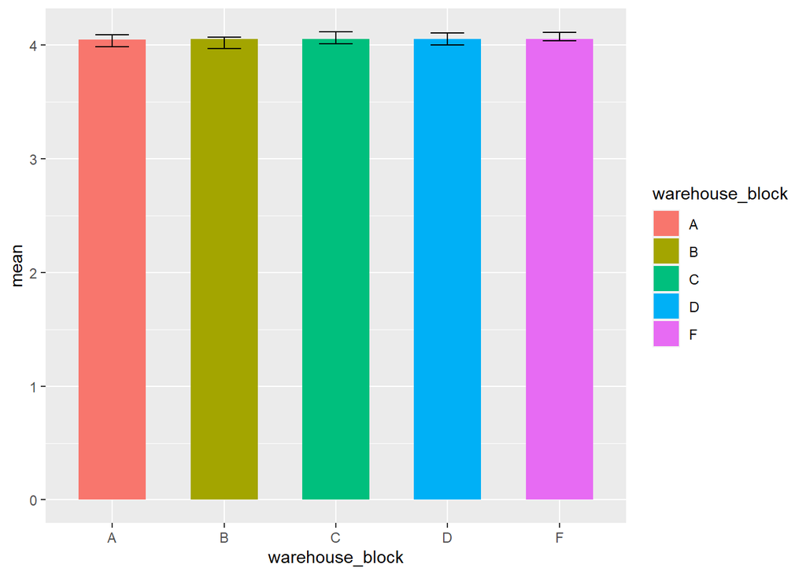

```r
block <- data.frame(warehouse_block="A",
                                mean=mean(female$customer_care_calls),
                                lower=aConf[1],
                                upper=aConf[2])

block<- rbind(block , data.frame(warehouse_block="B",
                                mean=mean(male$customer_care_calls),
                                lower=bConf[1],
                                upper=bConf[2]))
block<- rbind(block , data.frame(warehouse_block="C",
                                mean=mean(male$customer_care_calls),
                                lower=cConf[1],
                                upper=cConf[2]))
block<- rbind(block , data.frame(warehouse_block="D",
                                mean=mean(male$customer_care_calls),
                                lower=dConf[1],
                                upper=dConf[2]))
block<- rbind(block , data.frame(warehouse_block="F",
                                mean=mean(male$customer_care_calls),
                                lower=fConf[1],
                                upper=fConf[2]))

ggplot(block, aes(x=warehouse_block, y=mean, fill=warehouse_block)) +
  geom_bar(position="dodge", stat="identity", width = 0.6) +
  geom_errorbar(aes(ymin=lower, ymax=upper),
                width=.3,
                position=position_dodge(0.9))
```

## 4)Confidence interval that evaluates the total weight of the goods transported according to the type of shipping of the product.

```r
flight<- subset(data, mode_of_shipment=="Flight")
road <- subset(data, mode_of_shipment=="Road")
ship <- subset(data, mode_of_shipment=="Ship")
```

```r
flyConf <- t.test(flight$weight_gms)$conf.int
flyConf
```

```
## [1] 3555.008 3703.748
## attr(,"conf.level")
## [1] 0.95
```

The above output shows that the actual average product weights for flight shipping are between 3555.008 and 3703.748 with 95% confidence.

```r
roadConf <- t.test(road$weight_gms)$conf.int
roadConf
```

```
## [1] 3573.300 3725.801
## attr(,"conf.level")
## [1] 0.95
```

The above output shows that the actual average product weights for road shipping are between 3573.300 and 3725.801 with 95% confidence.

```r
shipConf <- t.test(ship$weight_gms)$conf.int
shipConf
```

```
## [1] 3594.121 3668.794
## attr(,"conf.level")
## [1] 0.95
```

The above output shows that the actual average product weights for ship shipping are between 3594.121 and 3668.794 with 95% confidence.

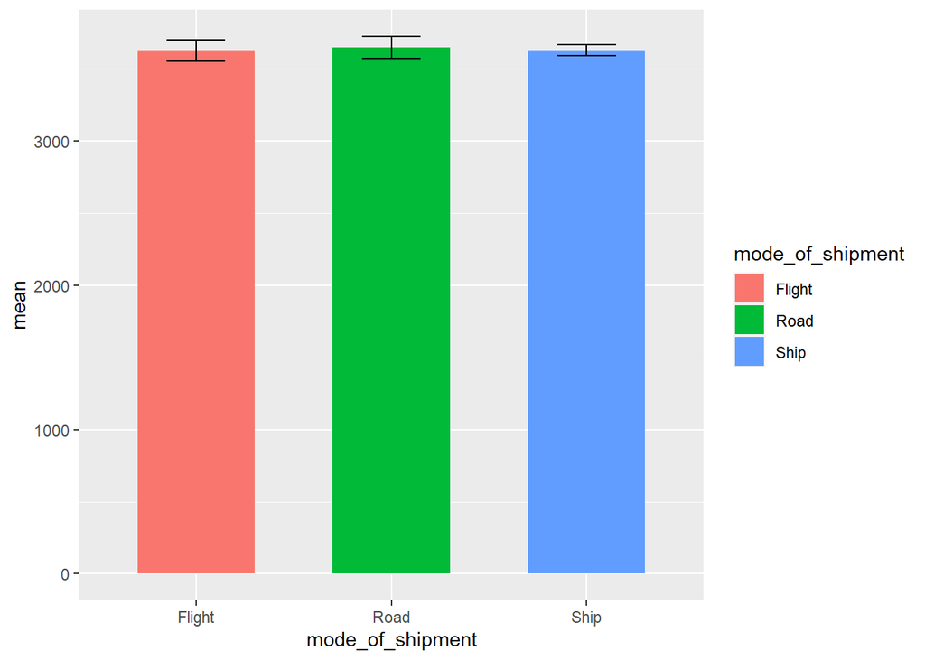

```r
shipping <- data.frame(mode_of_shipment="Flight",
                                mean=mean(flight$weight_gms),
                                lower=flyConf[1],
                                upper=flyConf[2])

shipping<- rbind(shipping , data.frame(mode_of_shipment="Road",
                                mean=mean(road$weight_gms),
                                lower=roadConf[1],
                                upper=roadConf[2]))

shipping<- rbind(shipping , data.frame(mode_of_shipment="Ship",
                                mean=mean(ship$weight_gms),
                                lower=shipConf[1],
                                upper=shipConf[2]))

ggplot(shipping, aes(x=mode_of_shipment, y=mean, fill=mode_of_shipment)) +
  geom_bar(position="dodge", stat="identity", width = 0.6) +
  geom_errorbar(aes(ymin=lower, ymax=upper),
                width=.3,
                position=position_dodge(0.9))
```

# Transformation

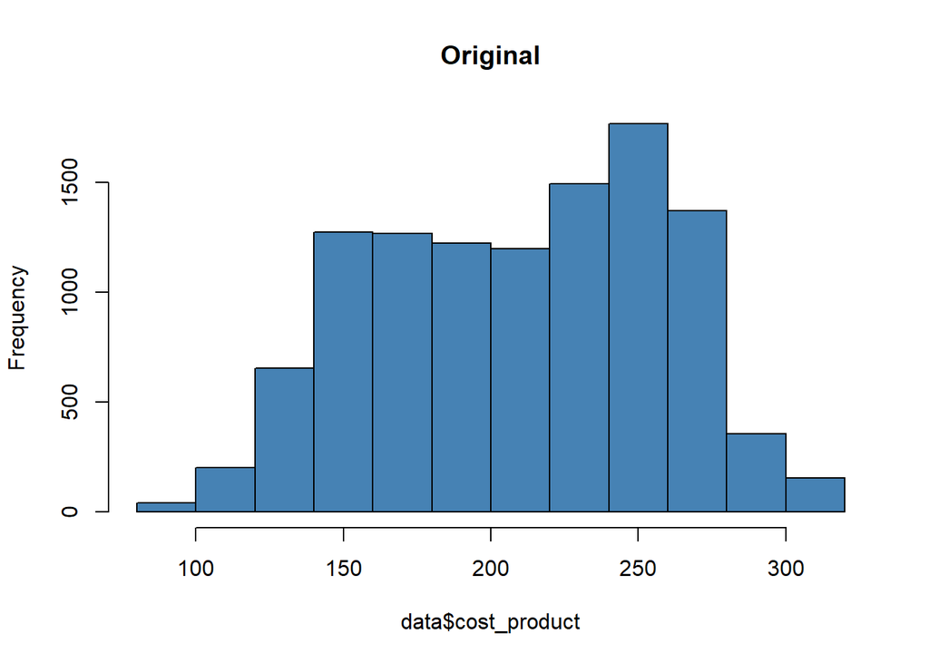

```r
data$logCostProduct=log10(data$cost_product)
hist(data$cost_product, col='steelblue', main='Original')
```

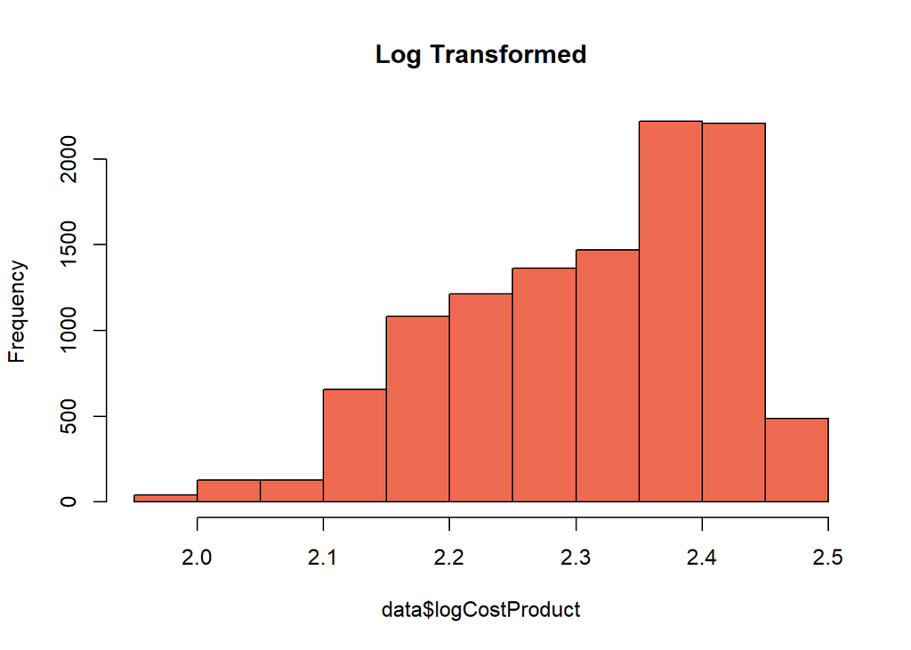

```r
hist(data$logCostProduct, col='coral2', main='Log Transformed')
```

```r
ad.test(data$cost_product)
```

```
##
##  Anderson-Darling normality test
##
## data:  data$cost_product
## A = 104.94, p-value < 2.2e-16
```

```r
ad.test(data$logCostProduct)
```

```
##
##  Anderson-Darling normality test
##
## data:  data$logCostProduct
## A = 162.56, p-value < 2.2e-16
```

We used the log transformation to normalize cost of products data.We tried to obtain a more normal distribution. The result log graph is not good but understandable.

# Hyphothesis Testing

## One Sample Test

```r
t.test(a$customer_care_calls,
       alternative = "less",
       mu=4,
       conf.level = 0.95)
```

```
##
##  One Sample t-test
##
## data:  a$customer_care_calls
## t = 1.4359, df = 1832, p-value = 0.9244
## alternative hypothesis: true mean is less than 4
## 95 percent confidence interval:
##      -Inf 4.081958
## sample estimates:
## mean of x
##  4.038189
```

In this QQ plot, we can see that the data is normally distributed.Values can pass linearly on the line.

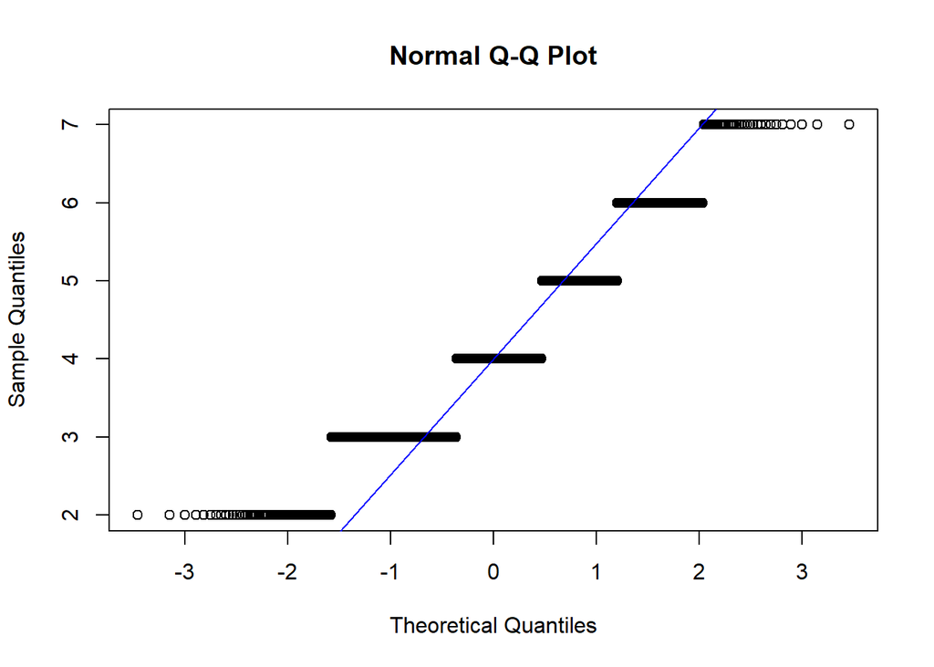

```r
qqnorm(a$customer_care_calls, ylab = "Sample Quantiles")
qqline(a$customer_care_calls,)
qqline(a$customer_care_calls, col = "blue")
```

```r
t.test(reached$prior_purchase,
       alternative = "less",
       mu=5,
       conf.level = 0.95)
```

```
##
##  One Sample t-test
##
## data:  reached$prior_purchase
## t = -80.191, df = 6562, p-value < 2.2e-16
## alternative hypothesis: true mean is less than 5
## 95 percent confidence interval:
##      -Inf 3.528906
## sample estimates:
## mean of x
##  3.498095
```

In this QQ plot, the values are more spread out of the line. Therefore, it does not show a normal distribution.

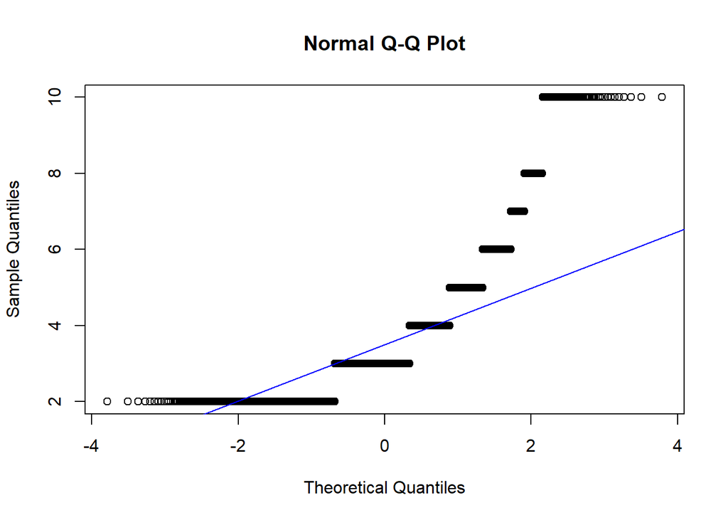

```r
qqnorm(reached$prior_purchase, ylab = "Sample Quantiles")
qqline(reached$prior_purchase,)
qqline(reached$prior_purchase, col = "blue")
```

### 3)One sample hypothesis of how weight the average product is for the way the product is shipping is the flight mode and tests it with a 95% confidence interval. H0: mu = 3600 H1: mu!= 3600

```r
t.test(flight$weight_gms,
       alternative = "two.sided",
       mu=3600,
       conf.level = 0.95)
```

```
##
##  One Sample t-test
##
## data:  flight$weight_gms
## t = 0.77477, df = 1776, p-value = 0.4386
## alternative hypothesis: true mean is not equal to 3600
## 95 percent confidence interval:
##  3555.008 3703.748
## sample estimates:
## mean of x
##  3629.378
```

In this QQ plot, the values are more spread out of the line. Therefore, it does not show a normal distribution.

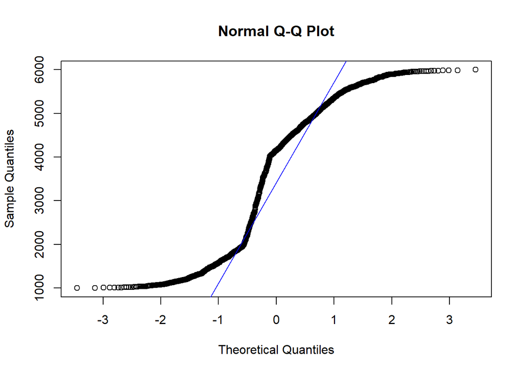

```r
qqnorm(flight$weight_gms, ylab = "Sample Quantiles")
qqline(flight$weight_gms,)
qqline(flight$weight_gms, col = "blue")
```

## Welch t-test

We used the Welch t-test in the 2 tests below.We used the welch t test in the 2 tests above.We used this test to compare the means between two independent groups and to examine whether there was a semantic relationship between these groups.

### 1)Is there a significant relationship between the gender of the customer and the average product costs? H0: mu = 210 H1: mu!= 210

```r
t.test(female$cost_product,male$cost_product,
       conf.level = 0.95,
       var.eq=F,
       paired=F)
```

```
##
##  Welch Two Sample t-test
##
## data:  female$cost_product and male$cost_product
## t = -2.0725, df = 10994, p-value = 0.03824
## alternative hypothesis: true difference in means is not equal to 0
## 95 percent confidence interval:
##  -3.695800 -0.102955
## sample estimates:
## mean of x mean of y
##  209.2550  211.1544
```

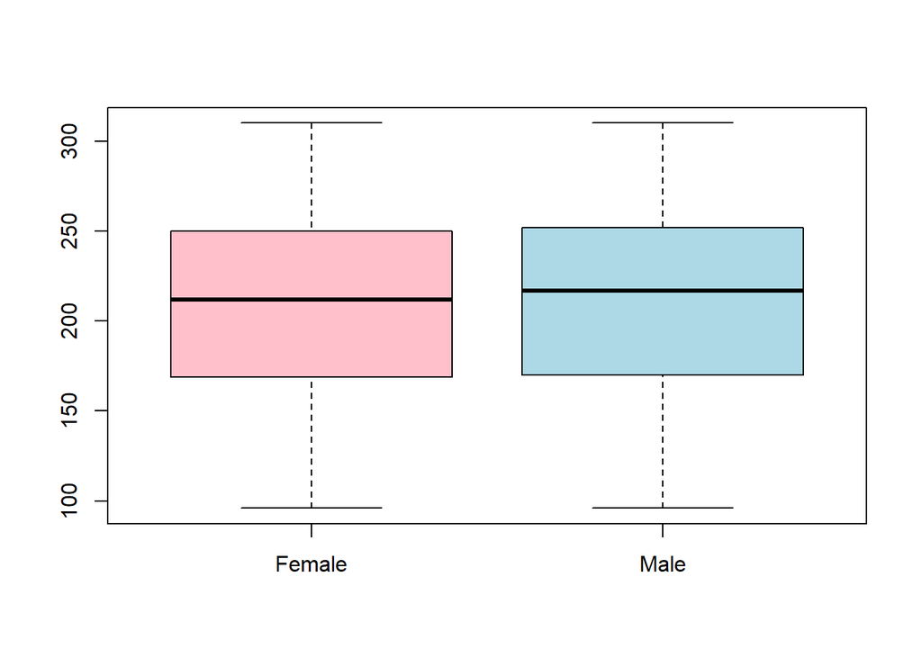

```r
boxplot(female$cost_product,male$cost_product,names=c("Female","Male"),col=c("pink","lightblue"))
```

Since this p-value < 0.05, we reject the null hypothesis and conclude that there is a statistically significant difference in the total price of products purchased between the male and female group.

The 95% confidence interval for the difference in the total price of products purchased between the two groups is [-3.695800, -0.102955].

The average price of the products purchased by the female group is 209.2550.

The average price of the products purchased by the male group is 211.1544.

Although the values are close to each other, as can be seen in the chart, the average price of the products bought by men is higher than the products bought by women.

### 2)Is there a significant relationship between the quality of the product and the weight of the product? H0: mu = 3700 H1: mu!= 3700

```r
low <- subset(data, product_importance=="low")
medium <- subset(data, product_importance=="medium")
high <- subset(data, product_importance=="high")

t.test(low$weight_gms,high$weight_gms,
       conf.level = 0.95,
       var.eq=F,
       paired=F)
```

```
##
##  Welch Two Sample t-test
##
## data:  low$weight_gms and high$weight_gms
## t = -9.5456, df = 1417.6, p-value < 2.2e-16
## alternative hypothesis: true difference in means is not equal to 0
## 95 percent confidence interval:
##  -612.4705 -403.6549
## sample estimates:
## mean of x mean of y
##  3497.489  4005.552
```

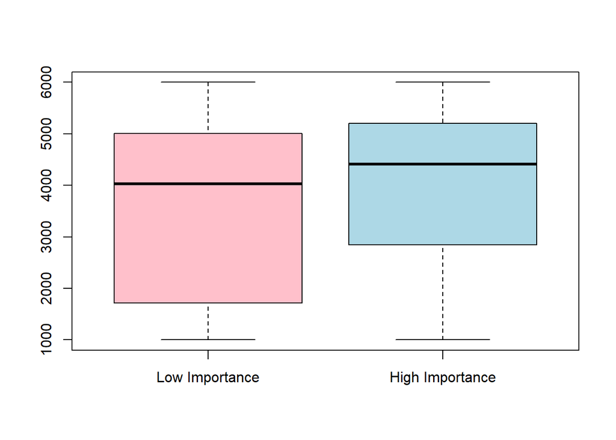

```r
boxplot(low$weight_gms,high$weight_gms, names=c("Low Importance","High Importance"),col=c("pink","lightblue"))
```

Since this p value is < 0.05, the null hypothesis is rejected and it is concluded that there is a significant difference between the importance of the products and the weights of the products sold.

The 95% confidence interval for the average weights of items sold between the two groups is [ -612.4705 -403.6549].

The average weight of low quality products shipped is 3497.489.

The average weight of high quality products shipped is 4005.552 .

As can be seen from the box plot, it is the products of high importance that have the highest average product weight.

## Paired t-test

### 1)Is there a semantic relationship between the price of the product sold and the discount offered to the product? H0: mu = 196 H1: mu!= 196

#### Assumption Check:

Normality assumption was checked using the Anderson-Darling test.

```r
ad.test(data$cost_product)
```

```
##
##  Anderson-Darling normality test
##
## data:  data$cost_product
## A = 104.94, p-value < 2.2e-16
```

```r
ad.test(data$discount_offered)
```

```
##
##  Anderson-Darling normality test
##
## data:  data$discount_offered
## A = 1417.2, p-value < 2.2e-16
```

Since p<0.05, the H0 hypothesis is rejected.

```r
t.test(data$cost_product,data$discount_offered,mu = 196,alternative="two.sided",conf.level = 0.95,paired = T)
```

```
##
##  Paired t-test
##
## data:  data$cost_product and data$discount_offered
## t = 1.6359, df = 10998, p-value = 0.1019
## alternative hypothesis: true difference in means is not equal to 196
## 95 percent confidence interval:
##  195.8367 197.8105
## sample estimates:
## mean of the differences
##                196.8236
```

The 95% confidence interval for the mean difference is (195.8367 197.8105).

The average difference between the price of the product and the discount on the product is 196.8236.

### 2)Is there a semantic relationship between the weight of the products and the price of the products? H0: mu = 3400 H1: mu!= 3400

#### Assumption Check:

Normality assumption was checked using the Anderson-Darling test.

```r
ad.test(data$weight_gms)
```

```
##
##  Anderson-Darling normality test
##
## data:  data$weight_gms
## A = 411.04, p-value < 2.2e-16
```

```r
ad.test(data$cost_produc)
```

```
##
##  Anderson-Darling normality test
##
## data:  data$cost_produc
## A = 104.94, p-value < 2.2e-16
```

Since p<0.05, the H0 hypothesis is rejected.

```r
t.test(data$weight_gms,data$cost_product,alternative="two.sided",mu=3400,conf.level = 0.95,paired = T)
```

```
##
##  Paired t-test
##
## data:  data$weight_gms and data$cost_product
## t = 1.521, df = 10998, p-value = 0.1283
## alternative hypothesis: true difference in means is not equal to 3400
## 95 percent confidence interval:
##  3393.122 3454.518
## sample estimates:
## mean of the differences
##                 3423.82
```

The 95% confidence interval for the mean difference is (3393.122 3454.518).

The average difference between the price of the product and the weight on the product is 3423.82.

## Fisher’s exact test

### Examining the reached on time of the purchased products according to the gender of the customer. H0:The gender and reached_on_time variables are independent HA:The gender and reached_on_time variables are dependent

```r
fishers<- with(data, table(gender, reached_on_time))
fishers
```

```
##       reached_on_time
## gender notReached Reached
##      F       2249    3296
##      M       2187    3267
```

```r
test <- fisher.test(fishers)
test
```

```
##
##  Fisher's Exact Test for Count Data
##
## data:  fishers
## p-value = 0.627
## alternative hypothesis: true odds ratio is not equal to 1
## 95 percent confidence interval:
##  0.943814 1.100813
## sample estimates:
## odds ratio
##   1.019305
```

```r
attributes(test)
```

```
## $names
## [1] "p.value"     "conf.int"    "estimate"    "null.value"  "alternative"
## [6] "method"      "data.name"
##
## $class
## [1] "htest"
```

## Annova Test

### 1)Is there a significant difference between the average of customer ratings for different mode of shipment? H0: μ1=μ2=μ3 H1: At least one is different

```r
anovaa <- data[, c(3, 5)]
names(anovaa) <- c("mode_of_shipment", "customer_rating")
head(anovaa)
```

```
##   mode_of_shipment customer_rating
## 1           Flight               2
## 2           Flight               5
## 3           Flight               2
## 4           Flight               3
## 5           Flight               2
## 6           Flight               1
```

```r
levels(anovaa$mode_of_shipment)
```

```
## [1] "Flight" "Road"   "Ship"
```

```r
group_by(anovaa, mode_of_shipment) %>%
  summarise(
    count = n(),
    mean = mean(customer_rating, na.rm = TRUE)
  )
```

```
## # A tibble: 3 x 3
##   mode_of_shipment count  mean
##   <fct>            <int> <dbl>
## 1 Flight            1777  2.98
## 2 Road              1760  3.00
## 3 Ship              7462  2.99
```

```r
summary(anovaa)
```

```
##  mode_of_shipment customer_rating
##  Flight:1777      Min.   :1.000
##  Road  :1760      1st Qu.:2.000
##  Ship  :7462      Median :3.000
##                   Mean   :2.991
##                   3rd Qu.:4.000
##                   Max.   :5.000
```

#### Assumption Check:

Normality assumption was checked using the Anderson-Darling test.

```r
ad.test(anovaa[anovaa$mode_of_shipment=="Flight", 2])
```

```
##
##  Anderson-Darling normality test
##
## data:  anovaa[anovaa$mode_of_shipment == "Flight", 2]
## A = 66.09, p-value < 2.2e-16
```

```r
ad.test(anovaa[anovaa$mode_of_shipment=="Road", 2])
```

```
##
##  Anderson-Darling normality test
##
## data:  anovaa[anovaa$mode_of_shipment == "Road", 2]
## A = 64.257, p-value < 2.2e-16
```

```r
ad.test(anovaa[anovaa$mode_of_shipment=="Ship", 2])
```

```
##
##  Anderson-Darling normality test
##
## data:  anovaa[anovaa$mode_of_shipment == "Ship", 2]
## A = 263.24, p-value < 2.2e-16
```

#### Variance homogeneity

```r
bartlett.test(customer_rating~mode_of_shipment, data = anovaa)
```

```
##
##  Bartlett test of homogeneity of variances
##
## data:  customer_rating by mode_of_shipment
## Bartlett's K-squared = 0.57054, df = 2, p-value = 0.7518
```

p-value > 0.05 based on barlett-test results. As a result, the null hypothesis is accepted, and the variances are all the same.

#### Analysis of variance

```r
variance<-aov(customer_rating~mode_of_shipment, data = anovaa)
summary(variance)
```

```
##                     Df Sum Sq Mean Sq F value Pr(>F)
## mode_of_shipment     2      0   0.080    0.04  0.961
## Residuals        10996  21977   1.999
```

Since the p value is > 0.05, it can be concluded that there are no significant differences in the customer rating depending on the shipment mode.

## Visualization

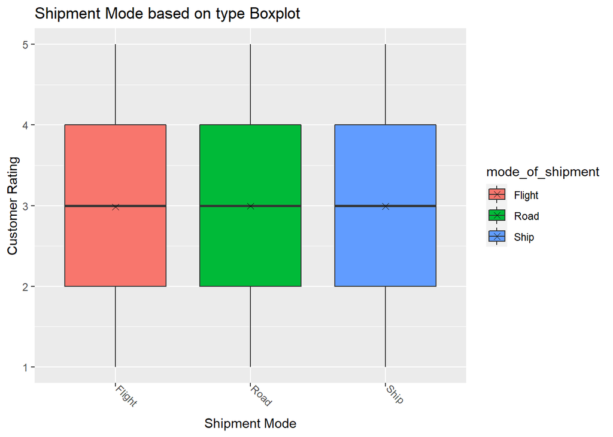

```r
ggplot(data=anovaa, aes(x=mode_of_shipment, y=customer_rating, fill= mode_of_shipment)) +
  geom_boxplot() +
  labs(title = "Shipment Mode based on type Boxplot", x = "Shipment Mode", y="Customer Rating") +
  stat_summary(fun=mean, geom="point", shape=4, size=2) +
  theme(axis.text.x=element_text(angle=-45,hjust=0,vjust=0))
```

X, Factor: Shipment Mode Y, Response: Customer Rating

### 2)Is there a significant difference between the average of weight for different warehouse? H0: μ1=μ2=μ3=μ4=μ5 H1: At least one is different

```r
anovaaa <- data[, c(2, 11)]
names(anovaaa) <- c("warehouse", "weight")
head(anovaaa)
```

```
##   warehouse weight
## 1         D   1233
## 2         F   3088
## 3         A   3374
## 4         B   1177
## 5         C   2484
## 6         F   1417
```

```r
levels(anovaaa$warehouse)
```

```
## [1] "A" "B" "C" "D" "F"
```

```r
group_by(anovaaa, warehouse) %>%
  summarise(
    count = n(),
    mean = mean(weight, na.rm = TRUE)
  )
```

```
## # A tibble: 5 x 3
##   warehouse count  mean
##   <fct>     <int> <dbl>
## 1 A          1833 3615.
## 2 B          1833 3636.
## 3 C          1833 3641.
## 4 D          1834 3629.
## 5 F          3666 3641.
```

#### Assumption Check:

Normality assumption was checked using the Anderson-Darling test.

```r
ad.test(anovaaa[anovaaa$warehouse=="A", 2])
```

```
##
##  Anderson-Darling normality test
##
## data:  anovaaa[anovaaa$warehouse == "A", 2]
## A = 71.915, p-value < 2.2e-16
```

```r
ad.test(anovaaa[anovaaa$warehouse=="B", 2])
```

```
##
##  Anderson-Darling normality test
##
## data:  anovaaa[anovaaa$warehouse == "B", 2]
## A = 68.778, p-value < 2.2e-16
```

```r
ad.test(anovaaa[anovaaa$warehouse=="C", 2])
```

```
##
##  Anderson-Darling normality test
##
## data:  anovaaa[anovaaa$warehouse == "C", 2]
## A = 68.674, p-value < 2.2e-16
```

```r
ad.test(anovaaa[anovaaa$warehouse=="D", 2])
```

```
##
##  Anderson-Darling normality test
##
## data:  anovaaa[anovaaa$warehouse == "D", 2]
## A = 63.876, p-value < 2.2e-16
```

```r
ad.test(anovaaa[anovaaa$warehouse=="F", 2])
```

```
##
##  Anderson-Darling normality test
##
## data:  anovaaa[anovaaa$warehouse == "F", 2]
## A = 138.91, p-value < 2.2e-16
```

#### Variance homogeneity

```r
bartlett.test(weight~warehouse, data = anovaaa)
```

```
##
##  Bartlett test of homogeneity of variances
##
## data:  weight by warehouse
## Bartlett's K-squared = 2.7247, df = 4, p-value = 0.6049
```

p-value > 0.05 based on barlett-test results. As a result, the null hypothesis is accepted, and the variances are all the same.

#### Analysis of variance

```r
variancee<-aov(weight~warehouse, data = anovaaa)
summary(variancee)
```

```
##                Df    Sum Sq Mean Sq F value Pr(>F)
## warehouse       4 9.834e+05  245852   0.092  0.985
## Residuals   10994 2.941e+10 2675342
```

Since the p value is > 0.05, it can be concluded that there are no significant differences in the weight depending on the warehouse.

## Visualization

[figure not shown]

```r
ggplot(data=anovaaa, aes(x=warehouse, y=weight, fill= warehouse)) +
  geom_boxplot() +
  labs(title = "warehouse based on type Boxplot", x = "Warehouse", y="Weight") +
  stat_summary(fun=mean, geom="point", shape=4, size=2) +
  theme(axis.text.x=element_text(angle=-45,hjust=0,vjust=0))
```

X, Factor: Warehouse Y, Response: Weight

## Tukey Test

```r
TukeyHSD(variance, conf.level=.95)
```

```
##   Tukey multiple comparisons of means
##     95% family-wise confidence level
##
## Fit: aov(formula = customer_rating ~ mode_of_shipment, data = anovaa)
##
## $mode_of_shipment
##                     diff         lwr        upr     p adj
## Road-Flight  0.012899678 -0.09854106 0.12434041 0.9602304
## Ship-Flight  0.008734331 -0.07873738 0.09620604 0.9702516
## Ship-Road   -0.004165347 -0.09197759 0.08364690 0.9932074
```

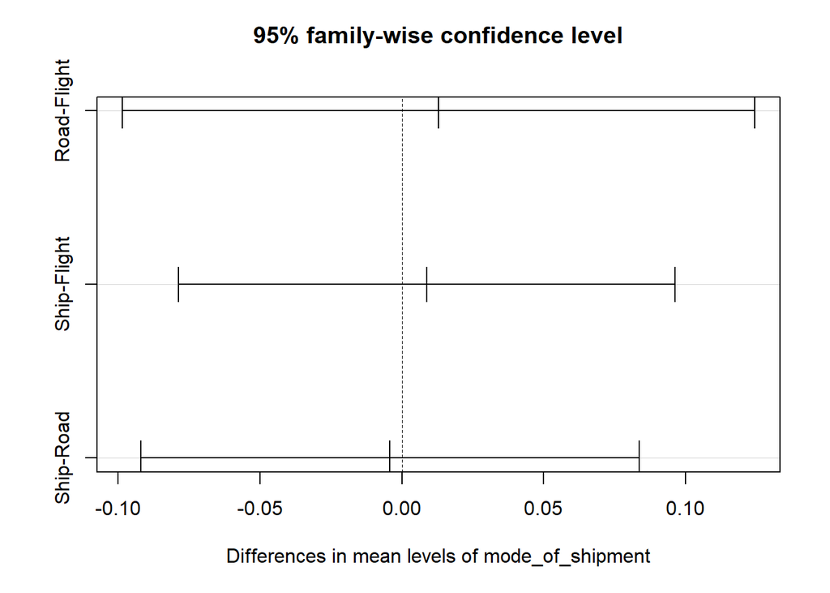

```r
plot(TukeyHSD(variance, conf.level=.95))
```

As a result, It is seen that there is no statistically significant difference in the mean loss between all groups. This is consistent with the fact that all p-values from our hypothesis tests were greater than 0.05.

```r
TukeyHSD(variancee, conf.level=.95)
```

```
##   Tukey multiple comparisons of means
##     95% family-wise confidence level
##
## Fit: aov(formula = weight ~ warehouse, data = anovaaa)
##
## $warehouse
##             diff       lwr      upr     p adj
## B-A  20.25204583 -127.1502 167.6543 0.9958091
## C-A  25.88216039 -121.5201 173.2844 0.9892691
## D-A  13.39779226 -133.9843 160.7799 0.9991669
## F-A  25.93862520 -101.7154 153.5927 0.9814291
## C-B   5.63011457 -141.7721 153.0323 0.9999734
## D-B  -6.85425356 -154.2364 140.5279 0.9999417
## F-B   5.68657938 -121.9675 133.3406 0.9999509
## D-C -12.48436813 -159.8665 134.8978 0.9993695
## F-C   0.05646481 -127.5976 127.7105 1.0000000
## F-D  12.54083294 -115.0900 140.1717 0.9988683
```

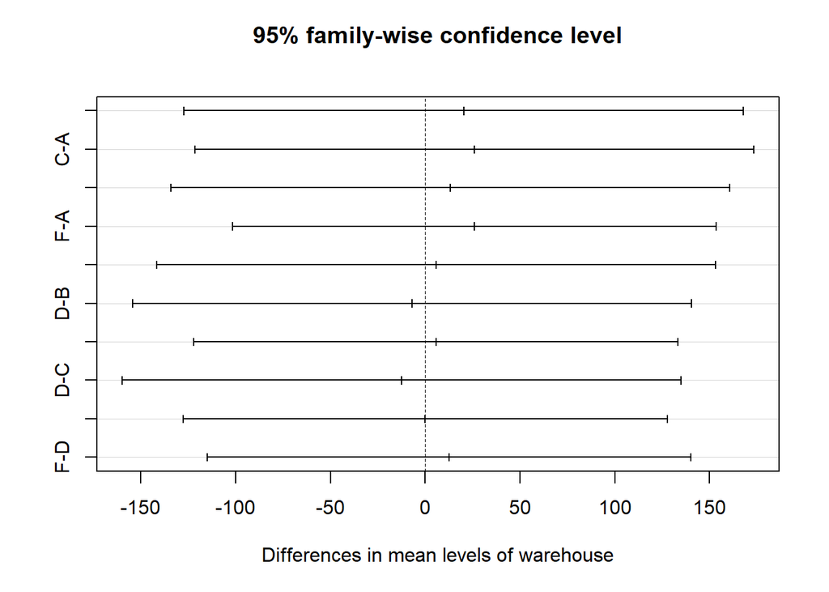

```r
plot(TukeyHSD(variancee, conf.level=.95))
```

As a result, It is seen that there is no statistically significant difference in the mean loss between all groups. This is consistent with the fact that all p-values from our hypothesis tests were greater than 0.05.

# Multiple Linear Regression

## Can a meaningful relationship be established between the price of the product and the weight of the product in grams, the discount offered to the product, and the importance of the product? H0= β1=β2=β3… = 0 H1= β != 0 for least one

In our model, product price is response variable, product weight, discount offered to the product and the importance of the product are explanatory variables.

```r
model1 <- lm(cost_product~weight_gms+discount_offered+product_importance,data=data)
summary(model1)
```

```
##
## Call:
## lm(formula = cost_product ~ weight_gms + discount_offered + product_importance,
##     data = data)
##
## Residuals:
##      Min       1Q   Median       3Q      Max
## -131.285  -37.892    4.991   38.066  107.670
##
## Coefficients:
##                            Estimate Std. Error t value Pr(>|t|)
## (Intercept)               2.383e+02  2.067e+00 115.299   <2e-16 ***
## weight_gms               -6.241e-03  2.953e-04 -21.137   <2e-16 ***
## discount_offered         -6.452e-01  2.968e-02 -21.741   <2e-16 ***
## product_importancelow     3.970e+00  1.653e+00   2.401   0.0164 *
## product_importancemedium  2.916e+00  1.662e+00   1.755   0.0793 .
## ---
## Signif. codes:  0 '***' 0.001 '**' 0.01 '*' 0.05 '.' 0.1 ' ' 1
##
## Residual standard error: 46.62 on 10994 degrees of freedom
## Multiple R-squared:  0.05934,    Adjusted R-squared:  0.059
## F-statistic: 173.4 on 4 and 10994 DF,  p-value: < 2.2e-16
```

In order to examine the significance of the model we established, we evaluated the p value by looking at the F statistic from the results.

Since the p value< 0.05, this model turns out to be statistically significant.That is, at least one explanatory variable in our model is associated with the response variable.

```r
summary(model1)$coef
```

```
##                               Estimate   Std. Error    t value      Pr(>|t|)
## (Intercept)              238.331042005 2.0670611222 115.299465  0.000000e+00
## weight_gms                -0.006240639 0.0002952529 -21.136586  3.105859e-97
## discount_offered          -0.645172763 0.0296755570 -21.740881 1.201922e-102
## product_importancelow      3.970383710 1.6533972593   2.401349  1.635125e-02
## product_importancemedium   2.915913393 1.6617255719   1.754750  7.932989e-02
```

```r
46.62/mean(data$cost)
```

```
## [1] 0.2217921
```

The p-value of the product weight, the discount offered, and the low-importance products is less than 0.05. Therefore, there is a significant relationship between them and our response variable, the price of the products.However, since the p value is greater than 0.05 for medium-important products, there is no significant relationship between the response variable, that is, the product price.

The price of average wages deviates from the estimated value by approximately 46.63.The error rate of the model is about 22%.

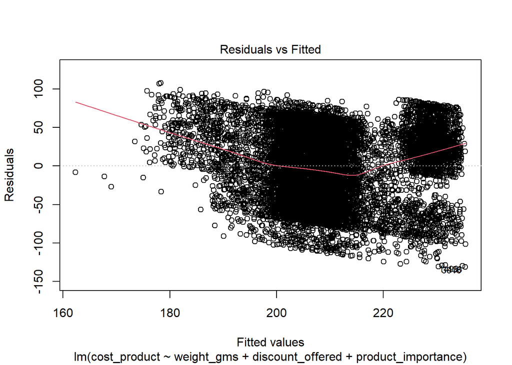

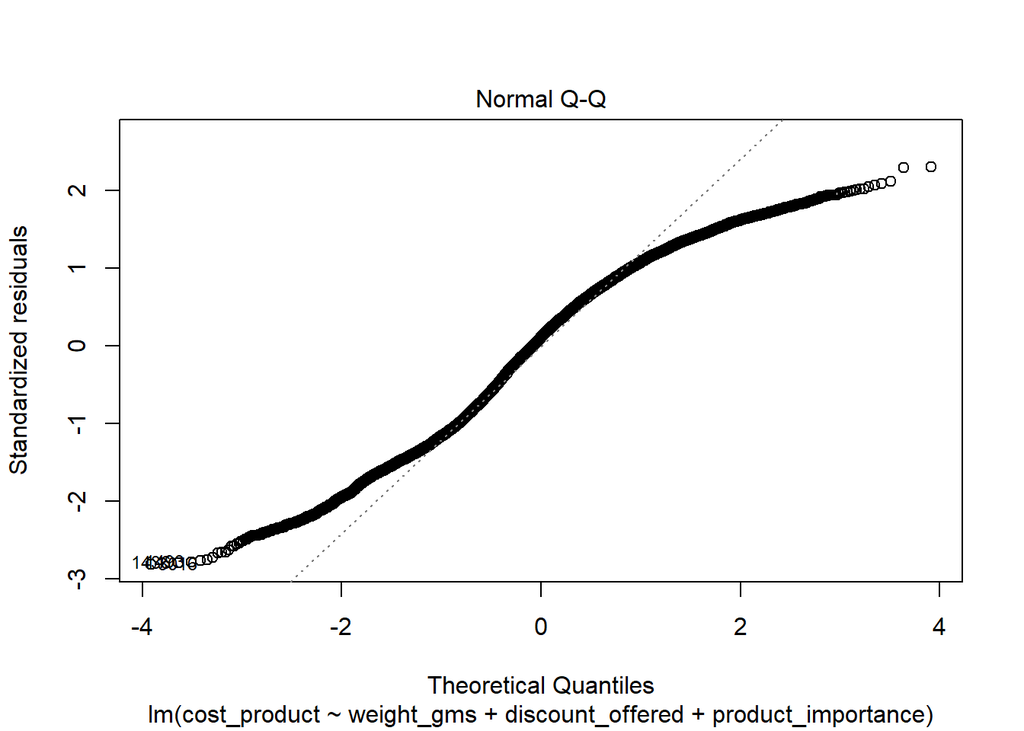

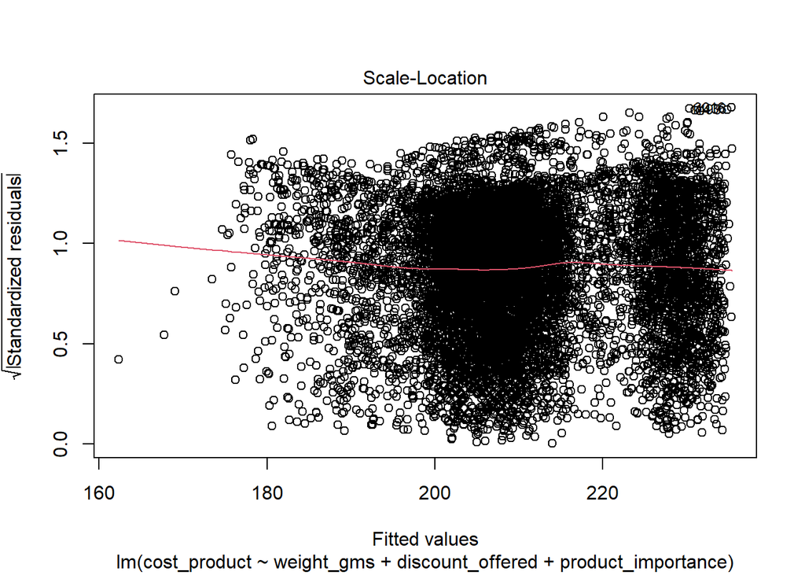

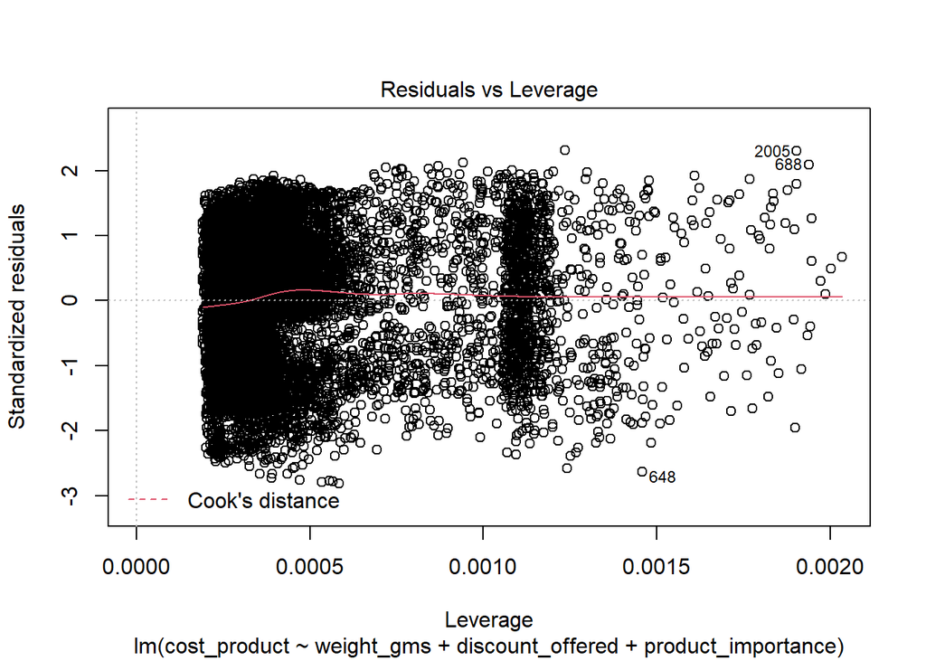

```r
plot(model1)
```

```r
model.final<-step(model1)
```

```
## Start:  AIC=84523.78
## cost_product ~ weight_gms + discount_offered + product_importance
##
##                      Df Sum of Sq      RSS   AIC
## <none>                            23898569 84524
## - product_importance  2     13059 23911628 84526
## - weight_gms          1    971149 24869718 84960
## - discount_offered    1   1027473 24926043 84985
```

```r
summary(model.final)
```

```
##
## Call:
## lm(formula = cost_product ~ weight_gms + discount_offered + product_importance,
##     data = data)
##
## Residuals:
##      Min       1Q   Median       3Q      Max
## -131.285  -37.892    4.991   38.066  107.670
##
## Coefficients:
##                            Estimate Std. Error t value Pr(>|t|)
## (Intercept)               2.383e+02  2.067e+00 115.299   <2e-16 ***
## weight_gms               -6.241e-03  2.953e-04 -21.137   <2e-16 ***
## discount_offered         -6.452e-01  2.968e-02 -21.741   <2e-16 ***
## product_importancelow     3.970e+00  1.653e+00   2.401   0.0164 *
## product_importancemedium  2.916e+00  1.662e+00   1.755   0.0793 .
## ---
## Signif. codes:  0 '***' 0.001 '**' 0.01 '*' 0.05 '.' 0.1 ' ' 1
##
## Residual standard error: 46.62 on 10994 degrees of freedom
## Multiple R-squared:  0.05934,    Adjusted R-squared:  0.059
## F-statistic: 173.4 on 4 and 10994 DF,  p-value: < 2.2e-16
```

### Prediction

Is there a meaningful relationship between the price of the product and whether the product reaches the destination on time and how much is received from the ordered product beforehand?  
We evaluated this using the best model of our original model.  
We kept our response variable the same and changed our explanatory variables.

```r
model.final<-lm(cost_product~reached_on_time+prior_purchase,data=data)
summary(model.final)
```

```
##
## Call:
## lm(formula = cost_product ~ reached_on_time + prior_purchase,
##     data = data)
##
## Residuals:
##      Min       1Q   Median       3Q      Max
## -130.463  -39.403    4.383   39.318  104.597
##
## Coefficients:
##                        Estimate Std. Error t value Pr(>|t|)
## (Intercept)            200.6021     1.3079 153.380  < 2e-16 ***
## reached_on_timeReached  -6.5570     0.9264  -7.078 1.56e-12 ***
## prior_purchase           3.7861     0.2985  12.686  < 2e-16 ***
## ---
## Signif. codes:  0 '***' 0.001 '**' 0.01 '*' 0.05 '.' 0.1 ' ' 1
##
## Residual standard error: 47.59 on 10996 degrees of freedom
## Multiple R-squared:  0.01976,    Adjusted R-squared:  0.01958
## F-statistic: 110.8 on 2 and 10996 DF,  p-value: < 2.2e-16
```

In order to examine the significance of the model we established, we evaluated the p value by looking at the F statistic from the results.

Since the p value< 0.05, this model turns out to be statistically significant.That is, at least one explanatory variable in our model is associated with the response variable.